# Memory_time_series

Ruoxi Liu

3/20/2020

```r
library(dplyr)
```

Uses TENxBrain Data 500k subset.

## HDF5

The codes for benchmarking are as the following:

"""

Rprof(filename = here(“main/case_studies/output/Memory_output”,paste0(method, out_name)), append = FALSE, memory.profiling = TRUE)

sce <- loadHDF5SummarizedExperiment(dir = here(“main/case_studies/data/subset/TENxBrainData”, data_name, paste0(data_name, "_preprocessed_best“)), prefix=”")

invisible(mbkmeans(counts(sce), clusters=k, batch_size = as.integer(dim(counts(sce))[2]*batch), num_init=1, max_iters=100))

Rprof(NULL)

"""

### 2% batch size (10,000 cells per batch)

```r
profile_hdf5_500k_0.02bs <- summaryRprof(filename = "/Users/April30/benchmark-hdf5-clustering/main/case_studies/output/Memory_output/hdf5TENxBrainData_500k_ruoxi_cluster_step1_Mar15235849.852_0.02.out", chunksize = -1L, memory = "tseries", diff = FALSE)
df_hdf5_500k_0.02bs <- rowSums(profile_hdf5_500k_0.02bs[,1:3])*0.00000095367432
df_hdf5_500k_0.02bs <- as.data.frame(df_hdf5_500k_0.02bs)

#line #1-259: loadHDF5SummarizedExperiment
#line #262-19213 : "mini_batch" ".local" "mbkmeans" "mbkmeans"
#line #19214-46105: predict_mini_batch_r

df_hdf5_500k_0.02bs_2 <- tibble::rownames_to_column(df_hdf5_500k_0.02bs, "Time")
df_hdf5_500k_0.02bs_2[which.max(df_hdf5_500k_0.02bs_2$df_hdf5_500k_0.02bs), ]
```

```
##        Time df_hdf5_500k_0.02bs
## 6529 130.58             17265.8
```

```r
#the peak of memory happens at the 130.58th second, with the usage of 16.86 GB (at line #6529).
profile_hdf5_500k_0.02bs["130.58",]
```

```
##        vsize.small vsize.large     nodes duplications
## 130.58    68451656 17684465784 351583400            0
##                      stack:2
## 130.58 "mbkmeans":"mbkmeans"
```

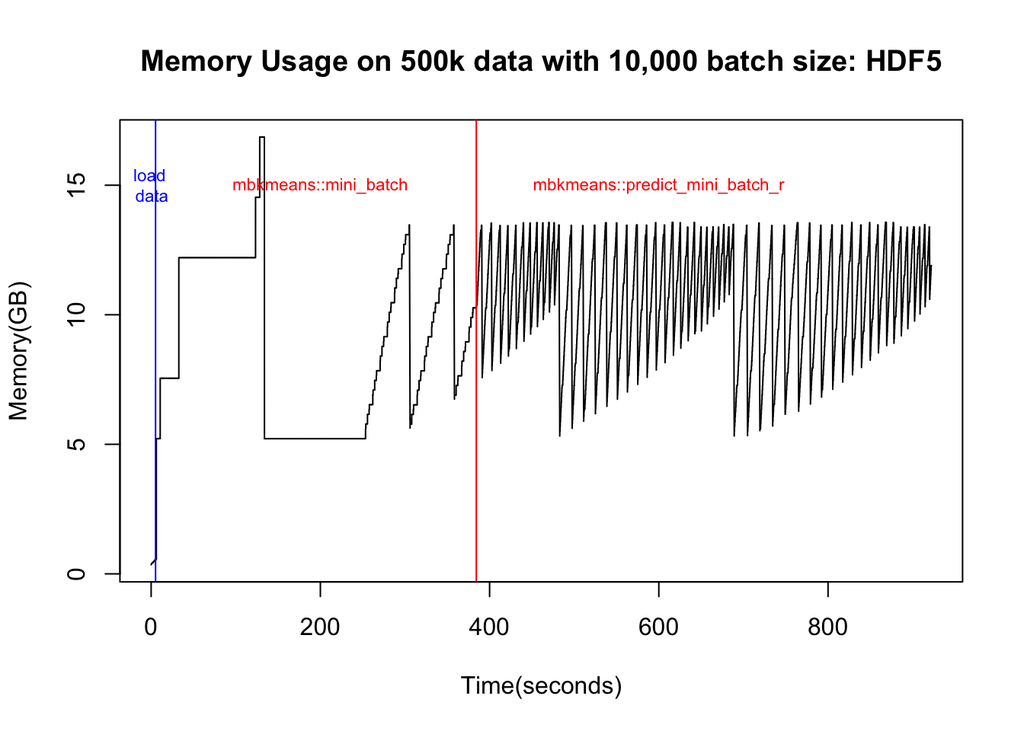

```r
plot(rownames(df_hdf5_500k_0.02bs),df_hdf5_500k_0.02bs$df_hdf5_500k_0.02bs/1024,type="l", xlab="Time(seconds)", ylab="Memory(GB)", main = "Memory Usage on 500k data with 10,000 batch size: HDF5")
abline(v=261*0.02, col="blue")
abline(v=19213*0.02, col="red")
text(1, 15, "load \ndata", cex = .7, col = "blue")
text(200, 15, "mbkmeans::mini_batch", cex = .7, col = "red")
text(600, 15, "mbkmeans::predict_mini_batch_r", cex = .7, col = "red")
```

### 0.2% batch size (1,000 cells per batch)

```r
profile_hdf5_500k_0.002bs <- summaryRprof(filename = "/Users/April30/benchmark-hdf5-clustering/main/case_studies/output/Memory_output/hdf5TENxBrainData_500k_ruoxi_cluster_step1_Mar15224414.914_0.002.out", chunksize = -1L, memory = "tseries", diff = FALSE)
df_hdf5_500k_0.002bs <- rowSums(profile_hdf5_500k_0.002bs[,1:3])*0.00000095367432
df_hdf5_500k_0.002bs <- as.data.frame(df_hdf5_500k_0.002bs)

#line #1-357: loadHDF5SummarizedExperiment
#line #361-16098 : "mini_batch" ".local" "mbkmeans" "mbkmeans"
#line #16099-49332: predict_mini_batch_r

df_hdf5_500k_0.002bs_2 <- tibble::rownames_to_column(df_hdf5_500k_0.002bs, "Time")
df_hdf5_500k_0.002bs_2[which.max(df_hdf5_500k_0.002bs_2$df_hdf5_500k_0.002bs), ]
```

```
##        Time df_hdf5_500k_0.002bs
## 7974 159.48              17265.8
```

```r
#the peak of memory happens at the 159.48th second, with the usage of 16.86 GB (at line #7974).
profile_hdf5_500k_0.02bs["159.48",]
```

```
##        vsize.small vsize.large     nodes duplications
## 159.48    68434376  5181902976 350939736            0
##                      stack:2
## 159.48 "mbkmeans":"mbkmeans"
```

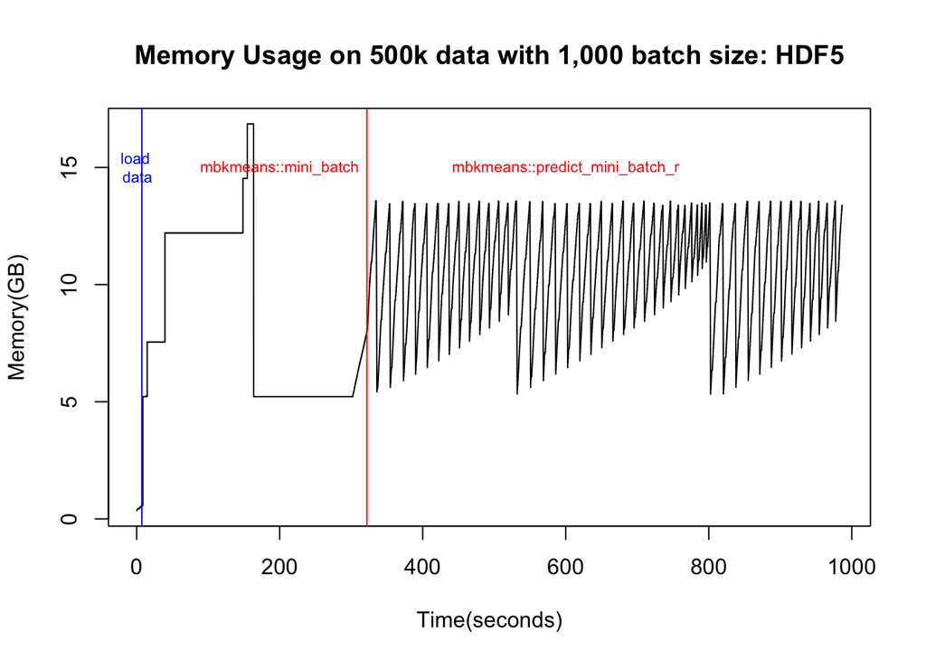

```r
plot(rownames(df_hdf5_500k_0.002bs),df_hdf5_500k_0.002bs$df_hdf5_500k_0.002bs/1024,type="l", xlab="Time(seconds)", ylab="Memory(GB)", main = "Memory Usage on 500k data with 1,000 batch size: HDF5")
abline(v=360*0.02, col="blue")
abline(v=16098*0.02, col="red")
text(1, 15, "load \ndata", cex = .7, col = "blue")
text(200, 15, "mbkmeans::mini_batch", cex = .7, col = "red")
text(600, 15, "mbkmeans::predict_mini_batch_r", cex = .7, col = "red")
```

## mbkmeans

The codes for benchmarking are as the following:

"""

Rprof(filename = here(“main/case_studies/output/Memory_output”,paste0(method, out_name)), append = FALSE, memory.profiling = TRUE)

sce <- loadHDF5SummarizedExperiment(dir = here(“main/case_studies/data/subset/TENxBrainData”, data_name, paste0(data_name, "_preprocessed_best“)), prefix=”")

sce_km <- realize(counts(sce))

invisible(mbkmeans(sce_km, clusters=k, batch_size = as.integer(dim(counts(sce))[2]*batch), num_init=1, max_iters=100))

Rprof(NULL)

"""

### 2% batch size (10,000 cells per batch)

```r
profile_mbkm_500k_0.02bs <- summaryRprof(filename = "/Users/April30/benchmark-hdf5-clustering/main/case_studies/output/Memory_output/mbkmeansTENxBrainData_500k_ruoxi_cluster_step1_Mar15235544.857_0.02.out", chunksize = -1L, memory = "tseries", diff = FALSE)
df_mbkm_500k_0.02bs <- rowSums(profile_mbkm_500k_0.02bs[,1:3])*0.00000095367432
df_mbkm_500k_0.02bs <- as.data.frame(df_mbkm_500k_0.02bs)

#line #1-249: loadHDF5SummarizedExperiment
#line #250-2719: realize
#line #2720-19037 : "mini_batch" ".local" "mbkmeans" "mbkmeans"
#line #19038-43815: predict_mini_batch_r

df_mbkm_500k_0.02bs_2 <- tibble::rownames_to_column(df_mbkm_500k_0.02bs, "Time")
df_mbkm_500k_0.02bs_2[which.max(df_mbkm_500k_0.02bs_2$df_mbkm_500k_0.02bs), ]
```

```
##         Time df_mbkm_500k_0.02bs
## 15781 315.62            28368.41
```

```r
#the peak of memory happens at the 315.62th second, with the usage of 27.70 GB (at line #15781).
profile_hdf5_500k_0.02bs["315.62",]
```

```
##        vsize.small vsize.large     nodes duplications
## 315.62    68541072  7188363976 356043184            0
##                      stack:2
## 315.62 "mbkmeans":"mbkmeans"
```

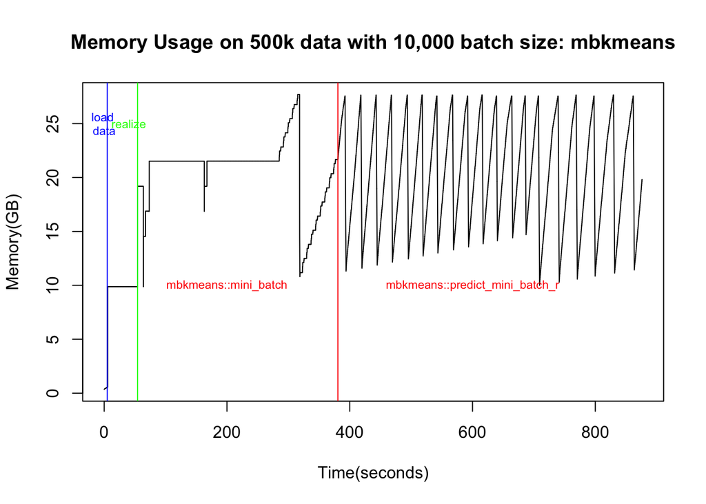

```r
plot(rownames(df_mbkm_500k_0.02bs),df_mbkm_500k_0.02bs$df_mbkm_500k_0.02bs/1024,type="l", xlab="Time(seconds)", ylab="Memory(GB)", main = "Memory Usage on 500k data with 10,000 batch size: mbkmeans")
abline(v=248*0.02, col="blue")
abline(v=2718*0.02, col="green")
abline(v=19036*0.02, col="red")
text(0.1, 25, "load \ndata", cex = .7, col = "blue")
text(40, 25, "realize", cex = .7, col = "green")
text(200, 10, "mbkmeans::mini_batch", cex = .7, col = "red")
text(600, 10, "mbkmeans::predict_mini_batch_r", cex = .7, col = "red")
```